# Multiple Logistic Regression

SDS 291

April 13, 2020

# Thoughts from HW

- Describing relationship between variables with a binary outcome
  - Quantitative Explanatory variable:
    - Can use xyplot, especially with jittered data
    - Boxplots
  - Binary Explanatory variable:
    - 2-by-2 tables: Conditional Proportions, Percentages
    - Bar chart
- Testing Linearity in Simple Logistic Regression (p.472-476)
  - Quantitative: Empirical Logits plot (‘binning’)
  - Binary: 2 points make a line

# Simple -> Multiple Regression

- More explanatory/predictor variables
- Combinations of variable types (quantitative, binary, categorical)
  - Transformed variables
  - Interactions

# Forms of the Model

- Logit form: $log(\frac{\pi}{1-\pi}) = \beta_0+\beta_1 X_1+\beta_2 X_2 + \cdot \cdot \cdot + \beta_k X_k$
- Probability form: $\pi = \frac{e^{\beta_0+\beta_1 X_1+\beta_2 X_2 + \cdot \cdot \cdot + \beta_k X_k}}{1+e^{\beta_0+\beta_1 X_1+\beta_2 X_2 + \cdot \cdot \cdot + \beta_k X_k}}$

If you’re asked to write the equation, express it in the logit form (unless the question asks specifically about probability).

# CFAU

- How to *choose* your model?
  - Depends on your goals, your research question, etc.
  - Choosing some components in advance to meet your stated hypotheses
- How do you *fit* the model?
  - Using `R`
  - Estimated models using maximum likelihood estimation
- How do you *assess* the model?
  - Are model assumptions met?
    - Linearity: empirical logit plots
    - Randomness & Independence: Knowing your data well
  - How good is the model?
    - Using -2log(L), nested likelihood ratio / drop-in-deviance test
- How do you *use* the model?
  - If you think the assumptions are met and reasonable for making inferences to the population, you can use the model
  - Statistical significance: p-values from z-test or likelihood ratio test
  - Specifying range of possible estimates: CI based on the z-statistics

# ICU - Can we predict Who survives?

A sample of 200 patients from the ICU. We have information on whether they survived

$$\begin{equation}
Survived=
\begin{cases}
0, & \text{Dead} \\
1, & \text{Lived}
\end{cases}
\end{equation}$$

and explanatory variables about their:

- age (`Age`, quantitative, years),
- AgeGroup (`AgeGroup`, categorical, 1=young (<50yo), 2=middle (50-69), 3=old(70+))
- sex (`Sex`, indictor/binary, 1=Female, 0=Male)
- Infection (`Infection`, indicator/binary, 1=infection is suspected, 0=no infection)
- Systolic Blood Pressure (`SysBP`, quantitative, mm/Hg), and
- Pulse (`Pulse`, quantitative, heart rate (beats per minute)),
- Emergency Admission (`Emergency`, indicator, 1=emergency admission, 0=elective admission)

```r
require(Stat2Data)
data("ICU")
```

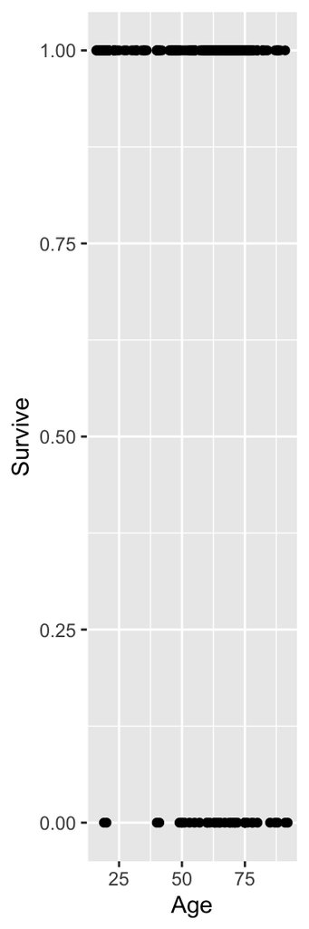

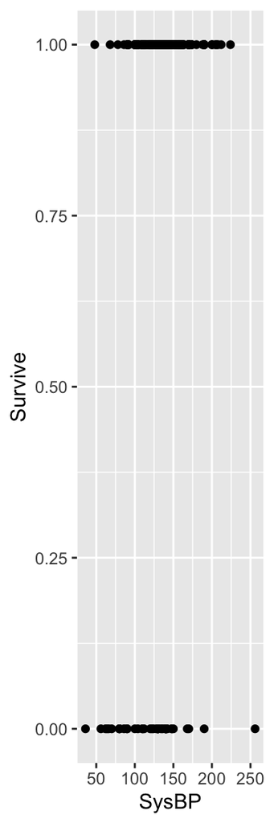

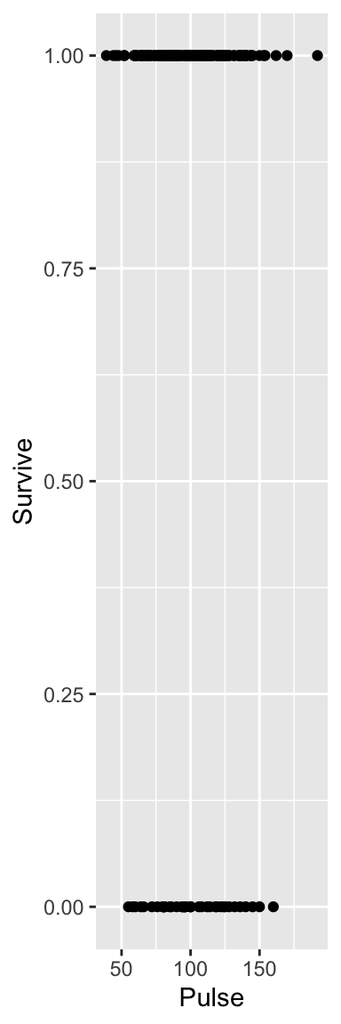

```
##         Survive
## AgeGroup  0  1
##        1  5 54
##        2 17 60
##        3 18 46
```

```
##    Survive
## Sex   0   1
##   0  24 100
##   1  16  60
```

```
##          Survive
## Infection   0   1
##         0  16 100
##         1  24  60
```

```
##          Survive
## Emergency   0   1
##         0   2  51
##         1  38 109
```

# Multiple Logistic Regression Model

```r
icu_m0 <- glm(Survive ~ Age+Sex+SysBP+Pulse, family=binomial, data=ICU)
summary(icu_m0)
```

```
##
## Call:
## glm(formula = Survive ~ Age + Sex + SysBP + Pulse, family = binomial,
##     data = ICU)
##
## Deviance Residuals:
##     Min       1Q   Median       3Q      Max
## -2.7833   0.3763   0.5351   0.7131   1.1073
##
## Coefficients:
##               Estimate Std. Error z value Pr(>|z|)
## (Intercept)  1.0630521  1.2285803   0.865   0.3869
## Age         -0.0282429  0.0108443  -2.604   0.0092 **
## Sex         -0.0380085  0.3822658  -0.099   0.9208
## SysBP        0.0167878  0.0058797   2.855   0.0043 **
## Pulse       -0.0009098  0.0067065  -0.136   0.8921
## ---
## Signif. codes:  0 '***' 0.001 '**' 0.01 '*' 0.05 '.' 0.1 ' ' 1
##
## (Dispersion parameter for binomial family taken to be 1)
##
##     Null deviance: 200.16  on 199  degrees of freedom
## Residual deviance: 183.23  on 195  degrees of freedom
## AIC: 193.23
##
## Number of Fisher Scoring iterations: 4
```

```r
exp(cbind(OR = coef(icu_m0), confint(icu_m0)))
```

```
##                    OR     2.5 %    97.5 %
## (Intercept) 2.8951940 0.2606642 33.359464
## Age         0.9721522 0.9502805  0.991884
## Sex         0.9627048 0.4579003  2.066474
## SysBP       1.0169295 1.0056558  1.029250
## Pulse       0.9990906 0.9861054  1.012533
```

```r
lrtest(icu_m0)
```

```
## Likelihood ratio test
##
## Model 1: Survive ~ Age + Sex + SysBP + Pulse
## Model 2: Survive ~ 1
##   #Df   LogLik Df  Chisq Pr(>Chisq)
## 1   5  -91.613
## 2   1 -100.080 -4 16.935    0.00199 **
## ---
## Signif. codes:  0 '***' 0.001 '**' 0.01 '*' 0.05 '.' 0.1 ' ' 1
```